# PSYC40940: Module overview

## Module name and code

PSYC40940: Visualisation of Behavioural Data and Data Dashboards

## Overview and aims

This module provides a comprehensive introduction to data visualisation and interactive data dashboards using state-of-the-art and industry-standard tools. Students are introduced to the theoretical principles of effective data visualisation, and gain extensive practical experience visualising a range of data types using a variety of plotting techniques. Interactive data visualisation and data dashboards are covered in depth. The module also provides a comprehensive introduction to producing publication-quality visualisations for scientific and other research reports, and covers how to produce these in a dynamic and reproducible manner.

For example, you will learn how to create beauties like this visualisation

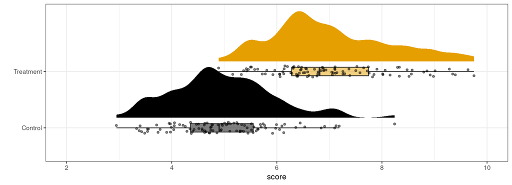

but we will also learn how to create interactive visualisations with software packages such as “plotly” and “Shiny” that allows the development of, among other things, data dashboards. Below is an example generated with “plotly” that allows you to interact with the visualisation.

[interactive chart not shown]

## Module content

Topics will be covered in this module include:

- Principles of data visualisation (e.g., as explained by the famous work of Edward R. Tufte).
- Use of a programming language, such as R, to produce visualisations of large and complex data sets.
- Major visualisation types such as histograms, density plots, boxplots, frequency polygons, area plots, line plots, uncertainty plots, violin plots, scatterplots, linear and nonlinear smoothers, heatmaps, contour plots, and geospatial maps.
- Approaches to visualising multiple distributions simultaneously on the same plot.
- Dynamic/programmatic production of static, publication-quality plots for presentations and reports.
- Generation of interactive graphics, using e.g. web apps, that allow for variable selection and parameter modification by users.
- Approaches to designing rich, interactive data dashboards that enable end users to explore data and seek insights for business intelligence and other purposes.

## Module learning outcomes

- MLO1: Demonstrate a critical understanding of the general principles of effective data visualisation.
- MLO2: Use state-of-the-art and industry-standard tools to produce high-quality, advanced visualisations of a range of large or complex data sets.
- MLO3: Use state-of-the-art and industry-standard tools to produce clear, publication-quality figures that adhere to the principles of reproducibility and data transparency.
- MLO4: Demonstrate a comprehensive, practical ability to produce high-quality interactive data visualisations and / or data dashboards that enable users to explore data and gain new insights.
- MLO5: Demonstrate independence, creativity, and an awareness of practical constraints when selecting and implementing approaches to data visualisation.

## Schedule

| Session | Date | Title |
| --- | --- | --- |
| 1 | 25/09/25 | Introduction to “Visualisation of Behavioural Data and Data Dashboards” |
| 2 | 02/10/25 | Foundations of Data Visualisation and ggplot2 |
| 3 | 09/10/25 | Exploring Aesthetics and Geometries |
| 4 | 16/10/25 | Major visualisation tools |
| 5 | 23/10/25 | Customising visualisations: scales, themes, and labels |
| 6 | 30/10/25 | Introduction to Shiny and Reactive Programming |
| 7 | 06/11/25 | Building Interactive UI Components |
| 8 | 13/11/25 | Linking ggplot2 with Shiny for Dynamic Visualisation |
| 9 | 20/11/25 | Creating and Deploying Dashboards |
| 10 | 27/11/25 | Wrap up |

## Indicative reading

- Andrews, M. (2021). Doing data science in R: an introduction for social scientists. Sage Publications.
- Tufte, E. R. (2001). The visual display of quantitative information. 2nd edition. Graphics Press.
- Wickham, H, & Grolemund, G. (2016). R for data science. O’Reilly Media.
- Wickham, H. (2021). Mastering shiny. O’Reilly Media